# Exploration of shared metaprograms across all subsets

Ally Hawkins

2026-06-15

This notebook summarizes the metrics used to identify shared metaprograms between all subsets and the full cohort metaprograms. Subsets were generated by randomly selecting a specified number of samples from the full cohort (N=10, 20, 30, 40, 50, 60, 70, 80, 90). Each subset was replicated 10 times. In addition, metaprograms were generated for the full cohort (102 samples) 10 times to test stability.

The input to this notebook is the TSV files output from `ews-nf` for each subset that contain:

- `overall_correlation`: Correlation of all gene weights
- `top_correlation`: Correlation of the top 200 gene weights
- `jaccard`: Jaccard index to measure the overlap of the top 200 genes

These metrics are calculated for all possible combinations of subset and full cohort metaprograms.

This notebook looks at the distribution of each metric and then uses various thresholds to define shared metaprograms. We then create saturation plots for each set of thresholds.

## Set up

```r
library(ggplot2)

# Set default ggplot theme
theme_set(
  theme_bw()
)
```

```r
# subset info file to get sample numbers for each subset
subset_info_file <- here::here("sample-info", "sample-subsets.tsv")

# read in subsets and add a column for how many samples in each subset id
subset_info_df <- readr::read_tsv(subset_info_file, col_types = list(.default = "c")) |>
  dplyr::count(subset_id, name = "num_samples")
```

```r
# path to the data directory and associated subset results
data_dir <- here::here("ews-nf-out", "metaprograms")

# comparison metrics output by ews-nf
metrics_files <- list.files(
  data_dir,
  pattern = "*_metaprograms-comparison-metrics.tsv",
  recursive = TRUE,
  full.names = TRUE
)

# grab the subset ids from the directory for each file
subset_ids <- dirname(metrics_files) |>
  stringr::word(-1, sep = "/")

# set the names of the files as the subset ids
names(metrics_files) <- subset_ids
```

```r
# read in all metrics files and combine into a single df
metrics_df <- metrics_files |>
  purrr::map(\(x)
    readr::read_tsv(x, col_types = list(.default = "d", subset_id = "c", subset_mp = "c", full_mp = "c"))
  ) |>
  dplyr::bind_rows(.id = "subset_id") |>
  # add the number of samples per subset
  dplyr::left_join(subset_info_df, by = "subset_id")
```

## Distribution of metrics

The first thing we will do is look at the distribution of each of these metrics. This will tell us if any of these metrics change as we increase the sample number, e.g., do we see an increase in the overall correlation and overlap if more samples are included. Each point is a comparison between a metaprogram in the subset to a metaprogram in the full cohort for 10 replicates.

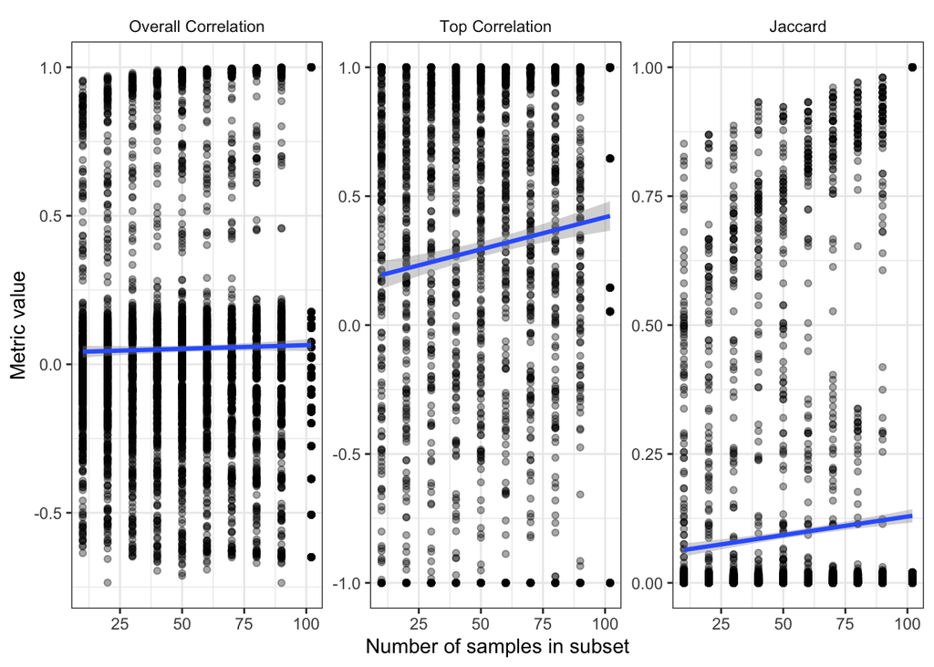

```r
# Reshape to long format for faceting
metrics_df_long <- metrics_df |>
  tidyr::pivot_longer(
    cols      = c(overall_correlation, top_correlation, jaccard),
    names_to  = "metric",
    values_to = "value"
  ) |>
  dplyr::mutate(metric = factor(metric,
    levels = c("overall_correlation", "top_correlation", "jaccard"),
    labels = c("Overall Correlation", "Top Correlation", "Jaccard")
  ))

ggplot(metrics_df_long, aes(x = num_samples, y = value)) +
  geom_point(alpha = 0.35, size = 1.4) +
  geom_smooth(method = "lm", se = TRUE, linewidth = 1.1) +
  facet_wrap(vars(metric), ncol = 3, scales = "free") +
  labs(
    x        = "Number of samples in subset",
    y        = "Metric value"
  ) +
  theme(
    strip.background = element_blank()
  )
```

Looking at this, we see what appears to be a positive relationship between the top correlation and Jaccard with no relationship for overall correlation. This tells us that even by including more samples, we aren’t impacting the overall correlation but the top correlation tends to become stronger. We see a similar trend with the Jaccard index.

It probably makes sense to continue with using thresholds for the Jaccard index and the top correlation to define a shared metaprogram.

## Saturation plots

Below we will look at the number of shared metaprograms per subset as a function of subset size. We expect that as we increase the number of samples, we will recover more metaprograms and eventually reach a point of saturation, where addition of more samples does not recover more metaprograms.

To do this, we’ll consider two different thresholds for both correlation (0.5 and 0.75) and Jaccard (0.3 and 0.6). For each full metaprogram, we’ll identify if the metaprogram is in the subset based on these two criteria.

Each point represents a replicate for the specified sample size.

```r
calculate_shared_mps <- function(df, corr_threshold, jaccard_threshold){

  # determine if the full metaprogram is shared with the subset
  # do this for each full metaprogram, so that the max number of shared metaprograms
  # is the number of metaprograms in the full cohort
  df_shared <- df |>
    dplyr::mutate(is_shared = top_correlation >= corr_threshold & jaccard >= jaccard_threshold) |>
    dplyr::group_by(subset_id, num_samples) |>
    dplyr::summarise(
      # avoid double counting situations where the full metaprogram maps to more than one subset metaprogram
      n_shared = dplyr::n_distinct(full_mp[is_shared]),
      n_total  = dplyr::n(),
      .groups  = "drop"
    )

  return(df_shared)
}

plot_saturation <- function(df_shared, corr_threshold, jaccard_threshold){

  ggplot(df_shared, aes(x = factor(num_samples), y = n_shared)) +
    ggforce::geom_sina(size = 2.5, alpha = 0.85, maxwidth = 0.7) +
    geom_smooth(aes(x = as.numeric(as.factor(num_samples))), method = "loess") +
    labs(
      title = glue::glue(
        "Thresholds: top correlation ≥ {corr_threshold}  |  Jaccard ≥ {jaccard_threshold}
        "
      ),
      x = "Number of samples",
      y = "Number of shared metaprograms"
    ) +
    ylim(0,8)
}
```

```r
# define the correlation options
corr_threshold <- c(0.5, 0.75)
jaccard_threshold <- c(0.3, 0.6)

# expand all combinations
threshold_combos_df <- tidyr::expand_grid(
  corr = corr_threshold,
  jaccard = jaccard_threshold
)
```

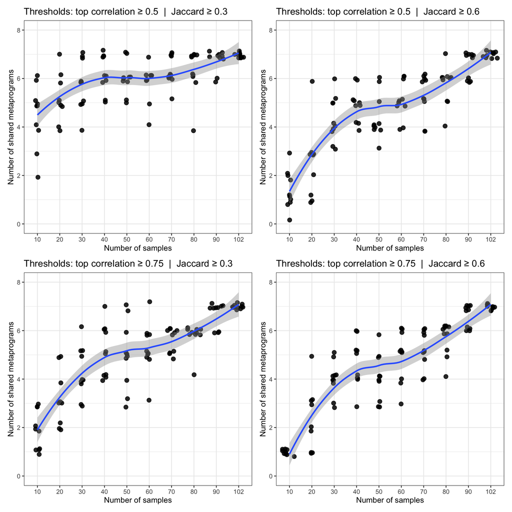

```r
# plot the saturation curve
plot_list <- threshold_combos_df |>
  purrr::pmap(\(corr, jaccard) {

    calculate_shared_mps(metrics_df, corr, jaccard) |>
      plot_saturation(corr, jaccard)

  })

patchwork::wrap_plots(plot_list)
```

In general, we do see that as we increase sample numbers we recover more shared metaprograms. However, changing the cutoffs definitely has an impact on the overall shape.

We would have to do more rigorous analysis to try and identify a true point of saturation here to find the minimum number of samples needed to capture all heterogeneity, but it might actually look like we need the full cohort?

One of the metaprograms, MP02 is capturing some noise and potentially ambient RNA. Let’s remove that metaprogram and then re-create the saturation plot.

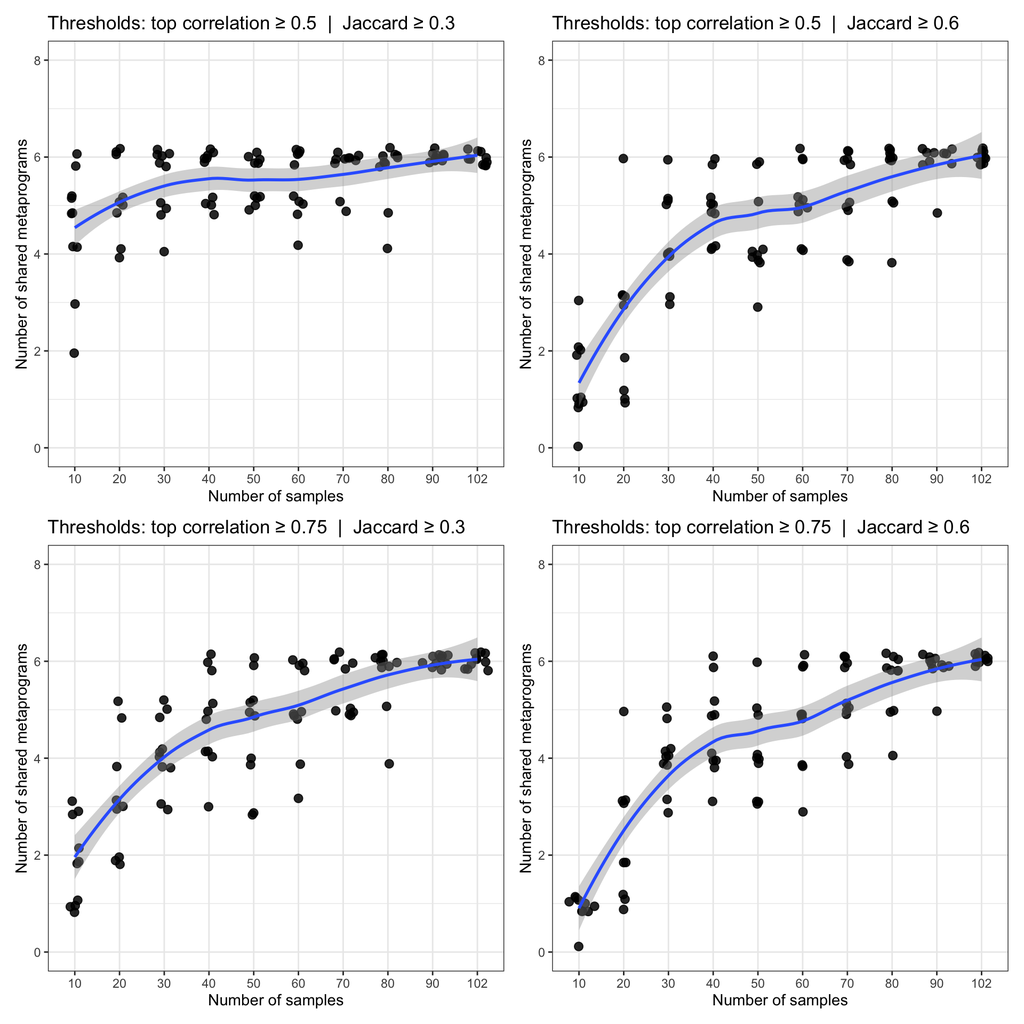

```r
# remove the noisy metaprogram
filtered_metrics_df <- metrics_df |>
  dplyr::filter(full_mp != "MP02")

# plot the saturation curve
plot_list <- threshold_combos_df |>
  purrr::pmap(\(corr, jaccard) {

    calculate_shared_mps(filtered_metrics_df, corr, jaccard) |>
      plot_saturation(corr, jaccard)

  })

patchwork::wrap_plots(plot_list)
```

Here we do see the curve flattens out around N=80 or N=90 rather than the positive slope that we see in the previous version. Maybe we are approaching a point of saturation if we don’t consider the “noisey” metaprogram?

## Shared metaprograms heatmap

```r
corr_threshold <- 0.75
jaccard_threshold <- 0.6

# calculate the percent of each subset with a shared metaprogram for a given full cohort metaprogram
heatmap_df <- metrics_df |>
  dplyr::mutate(
    # if top correlation wasn't calculated then no genes are shared so this should be 0
    top_correlation = ifelse(is.na(top_correlation), 0, top_correlation),
    is_shared = top_correlation >= corr_threshold,
    jaccard >= jaccard_threshold
  ) |>
  dplyr::summarise(
    subset_shares_mp = any(is_shared),   # TRUE if any subset MP matches this full MP
    .by = c("full_mp", "num_samples", "subset_id")
  ) |>
  dplyr::summarise(
    pct_shared = (sum(subset_shares_mp) / dplyr::n()) * 100,
    .by = c("full_mp", "num_samples")
  ) |>
  # add some meaningful names to each mp
  dplyr::mutate(
    full_mp = dplyr::case_when(
      full_mp == "MP01" ~ "MP01_EWS::FLI1-classic",
      full_mp == "MP02" ~ "MP02_noise",
      full_mp == "MP03" ~ "MP03_EWS::FLI1-low",
      full_mp == "MP04" ~ "MP04_inflammatory",
      full_mp == "MP05" ~ "MP05_myogenesis",
      full_mp == "MP06" ~ "MP06_cycling",
      full_mp == "MP07" ~ "MP07_unknown"
    )
  )
```

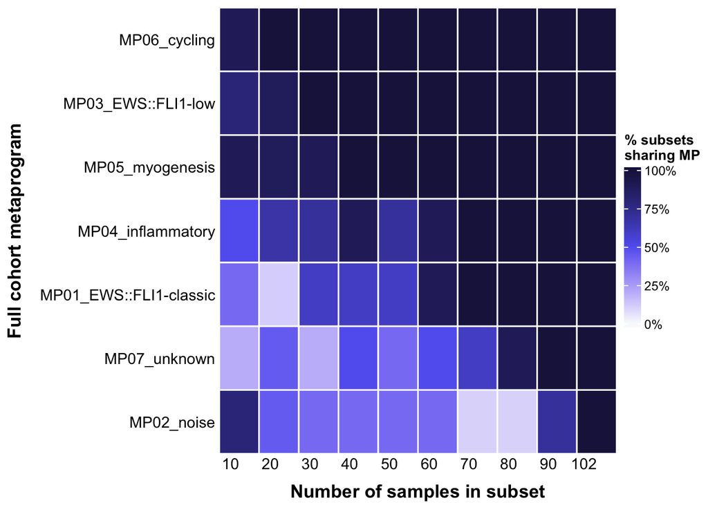

```r
# Build matrix: rows = full_mp, cols = num_samples
mat <- heatmap_df |>
  tidyr::pivot_wider(names_from = num_samples, values_from = pct_shared) |>
  tibble::column_to_rownames("full_mp") |>
  as.matrix()

# Sort columns numerically
mat <- mat[, order(as.numeric(colnames(mat)))]

# Colour scale: white (0%) → dark blue (100%)
col_fun <- circlize::colorRamp2(
  breaks = c(0, 50, 100),
  colors = c("#F8FAFC", "#6366F1", "#1E1B4B")
)

# Draw heatmap
ComplexHeatmap::Heatmap(
  mat,
  name                  = "% subsets\nsharing MP",
  col                   = col_fun,
  cluster_rows          = TRUE,
  cluster_columns       = FALSE,
  show_row_dend         = FALSE,
  row_names_side        = "left",
  row_names_gp          = grid::gpar(fontsize = 11),
  column_names_side     = "bottom",
  column_names_gp       = grid::gpar(fontsize = 11),
  column_names_rot      = 0,
  column_title          = "Number of samples in subset",
  column_title_side     = "bottom",
  column_title_gp       = grid::gpar(fontface = "bold", fontsize = 13),
  row_title             = "Full cohort metaprogram",
  row_title_gp          = grid::gpar(fontface = "bold", fontsize = 13),
  rect_gp               = grid::gpar(col = "white", lwd = 1.5),
  heatmap_legend_param  = list(
    title_gp      = grid::gpar(fontface = "bold", fontsize = 10),
    labels_gp     = grid::gpar(fontsize = 9),
    legend_height = grid::unit(4, "cm"),
    at            = c(0, 25, 50, 75, 100),
    labels        = c("0%", "25%", "50%", "75%", "100%")
  )
) |>
  ComplexHeatmap::draw(heatmap_legend_side = "right")
```

It looks like when you get to the N=70/N=80 mark you start to consistently capture every metaprogram except for MP02, which isn’t consistently captured until all samples are included. I don’t know that we want to consider “sharing” that metaprogram has a factor in identifying saturation?

Another interesting phenomenon here is that the EWS::FLI1 low, cycling, and myogenesis programs tend to be present in almost every subset no matter what size and are definitely present in every subset once you reach N=30. We don’t see consistent reproducibility of the inflammatory and EWS::FLI1 high programs until around N=60. MP07 is not consistent until N=90.